# Working with CYCLeR

Stefan R. Stefanov, Irmtraud M. Meyer

25. September 2020

**CYCLeR** is a pipeline for reconstruction of circRNA transcripts from RNA-seq data and their subsequent quantification. The algorithm relies on comparison between control total RNA-seq samples and circRNA enriched samples to identify circRNA specific features. Then the selected circRNA features are used to infer the transcripts through a graph-based algorithm. Once the predicted transcript set is assembled, the transcript abundances are estimated through an EM algorithm with **kallisto** [1]. **CYCLeR** takes as an input BAM files and back-splice junction (BSJ) files and outputs transcript infomation in different formats and a transcript abundance file.

## License of CYCLeR

The **CYCLeR** software is copyrighted 2020 by Stefan R. Stefanov and Irmtraud M. Meyer (irmtraud.meyer@cantab.net) and published under the [Creative Commons Attribution-NonCommercial-ShareAlike 4.0 International License](https://creativecommons.org/licenses/by-nc-sa/4.0/legalcode), a short summary of what this license entails can be found at [here](https://creativecommons.org/licenses/by-nc-sa/4.0/).

By using **CYCLeR** software, you also agree to citing the corresponding **CYCLeR** publication in your own scientific publications that use **CYCLeR** or parts thereof.

## Installation of CYCLeR

### Command line tools needed

```r
**STAR** - https://github.com/alexdobin/STAR
**samtools** - https://sourceforge.net/projects/samtools/files/samtools/
**kallisto** - http://pachterlab.github.io/kallisto/download
#We also suggest RStudio to supplement the interactive experience
**RStudio** - https://rstudio.com/products/rstudio/download/
```

### R packages needed

```r
install.packages("tidyverse")
if (!requireNamespace("BiocManager", quietly = TRUE))
    install.packages("BiocManager")
BiocManager::install(c("SGSeq","DEXSeq","polyester"))
#Those packages need to be selected based on the model organism
BiocManager::install(c("org.Dm.eg.db","TxDb.Dmelanogaster.UCSC.dm6.ensGene","BSgenome.Dmelanogaster.UCSC.dm6"))
#also the CYCLeR_functions need to be added
source('.../CYCLeR_functions.R')
```

## Pre-processing the data

### Mapping with STAR

The STAR [2] mapping parameters are up to a personal preference. It is imperative to include the **intronMotif** tag. My suggestion would be 2-pass mapping with these parameters:

```r
#first pass
STAR --alignSJoverhangMin 5 --outSAMstrandField intronMotif --outFilterMismatchNmax 3
--outFilterMismatchNoverLmax 0.1
--chimSegmentMin 15 --chimScoreMin 1 --chimJunctionOverhangMin 15
--outFilterMultimapNmax 50 --alignIntronMax 100000 --alignIntronMin 15
#second pass
STAR --outSAMstrandField intronMotif --outFilterMismatchNmax 7 --outFilterMismatchNoverLmax 0.3
--alignSJoverhangMin 15 --alignSJDBoverhangMin 3
--chimSegmentMin 15 --chimScoreMin 1 --chimJunctionOverhangMin 15
--outFilterMultimapNmax 50 --alignIntronMax 100000 --alignIntronMin 15
#converting to sorted BAM
samtools view -u -h Aligned.out.sam | samtools sort <name>_sorted.bam
```

### Processing the BAM info in R

We need the information for read length, fragment length and library sizes from the BAM files.

```r
#load the BSJ files
bam_file_prefix<-<path to files>
filenames<-<sample1,sample2,sample3,sample4>
BSJ_files_ciri<-paste0(BSJ_files_prefix,filenames)
bam_files<-paste0(bam_file_prefix,filenames,"_sorted.bam")
#mark the samples control and enriched or bare the consequences
sample_table<-data.frame(filenames,c("control","control","enriched","enriched"),bam_files,stringsAsFactors = F)
colnames(sample_table)<-c("sample_name","treatment","file_bam")
si<- DataFrame(sample_table[,c("sample_name","file_bam")])
si$file_bam <-BamFileList(si$file_bam, asMates = F)
#this holds all the needed info of the bam files for downstream processing
sc <- getBamInfo(si)
sample_table$lib_size<-sc@listData$lib_size
sample_table$read_len<-sc@listData$read_length
```

**Use** the provided sample table template.

```r
print(sample_table)
```

```
##   sample_name treatment                                          file_bam
## 1  SRR1191323   control /home/sstefan/data/wt_vs_RR/SRR1191323_sorted.bam
## 2  SRR1191331   control /home/sstefan/data/wt_vs_RR/SRR1191331_sorted.bam
## 3  SRR1191327  enriched /home/sstefan/data/wt_vs_RR/SRR1191327_sorted.bam
## 4  SRR1191335  enriched /home/sstefan/data/wt_vs_RR/SRR1191335_sorted.bam
##   lib_size read_len
## 1 19255420      101
## 2 15068605      101
## 3 17144585      101
## 4 18667943      101
```

### Selecting a BSJ set

Selecting a BSJ set is very important, because the algorithm assumes that the provided set of BSJ is *correct*. I suggest BSJ identification with **CIRI2** [3] and **CIRCexplorer2** [4], but the choice is up to a personal preference. I have provided some useful functions for parsing the output from BSJ identification software.

```r
#load the BSJ files
BSJ_files_prefix<-"/home/sstefan/data/wt_vs_RR/ciri/ciri_"
ciri_table<-parse.files(BSJ_files_ciri,file_path="","CIRI")
ciri_bsjs<-process.BSJs(ciri_table,sample_table)
# i would suggest combine the output of pipelines using different mapping tools
BSJ_files_prefix_CE<-"~/data/wt_vs_RR/CE/CE_"
ce_table<-parse.files(sample_table$sample_name,BSJ_files_prefix_CE,"CE")
ce_bsjs<-process.BSJs(ce_table,sample_table)
#we need to unify the results from the BSJ identification and counting
table_circ<-combine.two.BSJ.tables(ce_bsjs,ciri_bsjs)
#further downstream we need just the mean values for enriched samples
table_circ<-table_circ[,c("chr","start","end","meanRR")]
colnames(table_circ)<-c("chr","start","end","count")
#combine
BSJ_set<-union(ciri_bsjs$circ_id,ce_bsjs$circ_id)
BSJ_set<-BSJ_set[!grepl("caffold",BSJ_set)]#just in case
BSJ_set<-BSJ_set[!grepl("mitochondrion",BSJ_set)]
###############################################################
#converting the BSJ set into a GRanges object
BSJ_gr<-make.BSJ.gr(BSJ_set)
```

The parse.files can work with **CIRI2**, **CIRCexplorer2** or **TSV** file. Naturally a person may have different criterion for *correct* BSJs based on different criteria. It is not an issue as long as the data is presented in the following template:

```r
head(table_circ)
```

```
## # A tibble: 6 x 4
##   chr   start    end      count
##   <chr> <chr>    <chr>    <dbl>
## 1 2L    10036818 10037279 1.18
## 2 2L    10080375 10081946 0.923
## 3 2L    10096914 10098010 0.332
## 4 2L    10096914 10137559 0.292
## 5 2L    10104792 10114895 0.268
## 6 2L    10120720 10122038 0.260
```

## Transcript assembly

### BSJ loci extraction

Prior to the feature detection the files need to be trimmed to speed up the process. Afterwards the transcript features (e.g. exons, junctions) are identified with **SGSeq** [5]. The files are convereted with **samtools** [6].

```r
####################################################
#get the gene/transcript info
#restoreSeqlevels(txdb)
txdb <- TxDb.Dmelanogaster.UCSC.dm6.ensGene
txdb <- keepSeqlevels(txdb, c("chr2L","chr2R","chr3R","chr3L","chr4","chrX","chrY"))
seqlevelsStyle(txdb) <- "Ensembl"
gene_ranges <- genes(txdb)
txf <- convertToTxFeatures(txdb)
#asnnotation as sg-object
sgf <- convertToSGFeatures(txf)
###################################################
samtools_prefix<-"/home/sstefan/software/samtools-1.10/bin/"
trimmed_bams<-filter.bam(BSJ_gr,sample_table,samtools_prefix)
sc@listData[["file_bam"]]<-trimmed_bams
#sc@listData[["sample_name"]]<-sample_table_ce$sample_name
```

### Feature identification with SGSeq

```r
sgfc_pred <- analyzeFeatures(sc, min_junction_count=2, beta =0.1 , min_n_sample=1,cores=1,verbose=F)
sgfc_pred <- SGSeq::annotate(sgfc_pred, txf)
```

**SGSeq** feature plotting function can be used for visual representation of the control VS enriched difference

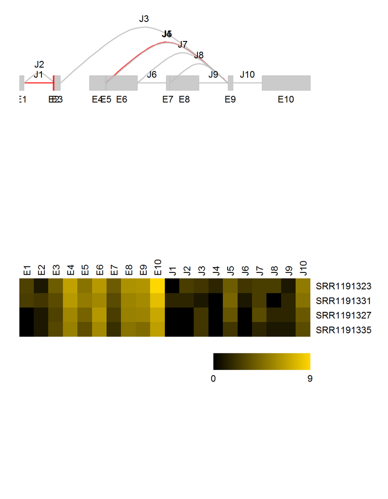

```r
plotFeatures(sgfc_pred,  geneID = "1",assay = "counts",color_novel = "red", include = "both",tx_view=F,Rowv=NA, square=T)
```